# Credit Risk Classification with Numeric and Categorical Attributes: Exploring Cost Matrix Impact

- Project by: Ahmed Shehata
- e-mail:ahmed1979fcb@gmail.com
- Linkedin:www.linkedin.com/in/shehata-ahmed
- Website: https://ahmedshehata2002.github.io/Portfolio-/

## Objective

In this project, we aim to develop a predictive model using machine learning classification techniques to assess whether individuals seeking loans pose a risk of defaulting or not. Leveraging a dataset containing a variety of independent variables such as checking account balance, credit history, purpose, and loan amount, our objective is to create a robust model that accurately categorizes loan applicants as either defaulters or non-defaulters. Through the utilization of both numeric and categorical attributes, we seek to enhance the predictive capabilities of our model. Additionally, the exploration of a cost matrix will allow us to analyze the impact of misclassification costs on model performance and refine our classification strategy for improved accuracy and reliability in credit risk assessment. Data from: https://archive.ics.uci.edu/ml/datasets/statlog+(german+credit+data)

### Key Steps in Developing Decision Tree Models for Credit Risk Classification

1. Data Summary: Initially, we'll summarize the dataset, exploring its structure, dimensions, and the nature of its variables. This step involves understanding the dataset's composition and identifying any missing values or outliers that may require preprocessing.
2. Univariate and Bivariate Analysis: Following data summary, we'll conduct univariate analysis to explore individual variables' distributions and characteristics. Then, we'll proceed to bivariate analysis to examine relationships between pairs of variables and uncover potential patterns or correlations.
3. Exploratory Data Analysis (EDA): EDA involves a comprehensive exploration of the dataset using statistical techniques and data visualization methods. This step helps us gain deeper insights into the data, identify trends, patterns, and anomalies, and inform subsequent modeling decisions.
4. Training the Data: After EDA, we'll prepare the data for model training by splitting it into training and testing sets. The training set will be used to train our machine learning models, while the testing set will evaluate model performance and generalization to unseen data.
5. Decision Tree Model Creation: We will proceed to create decision tree models using the training dataset. Decision trees are powerful classifiers that partition the feature space into distinct regions based on the feature values, enabling intuitive interpretation and predictive modeling.
6. Visualization of Decision Trees: Once the decision tree models are trained, we'll visualize them to gain insights into their structure and decision-making processes. Visualizing decision trees helps understand how the model segments the data and makes predictions based on feature values.
7. Assessment of Feature Importances using GINI: Finally, we'll assess the importance of features in our decision tree models using the GINI impurity criterion. GINI impurity measures the extent of class impurity within a node, and feature importances derived from GINI provide valuable insights into the predictive power of each feature in the model.
8. Reassessment and Pruning Techniques: Following initial model development, we will reassess the model's performance and explore various pruning techniques to refine and optimize the decision tree structure. Pruning helps prevent overfitting and improves model generalization by simplifying complex trees.
9. Final Model Summary, Recommendations, and Conclusion: In this concluding step, we will provide a comprehensive summary of the final decision tree model, including its performance metrics, feature importances, and insights gained through the analysis. Based on the model outcomes, we will offer actionable recommendations for credit risk assessment practices. Finally, we will conclude with key takeaways and insights drawn from the entire modeling process.

By following these steps systematically, we aim to develop a robust decision tree model for credit risk classification, leveraging exploratory analysis and feature importance assessment to enhance model interpretability and predictive performance.

```python
! pip install black
```

```python
# Libraries to help with reading and manipulating data
import pandas as pd
import numpy as np

# Libaries to help with data visualization
import matplotlib.pyplot as plt
import seaborn as sns

# Library to split data and manipulate it
from sklearn.model_selection import train_test_split
from sklearn import metrics
from sklearn.tree import DecisionTreeClassifier
from sklearn import tree
# to build linear regression_model
from sklearn.linear_model import LinearRegression
# to check model performance
from sklearn.metrics import mean_absolute_error, mean_squared_error, r2_score
# to build linear regression_model using statsmodels
import statsmodels.api as sm
# to compute VIF
from statsmodels.stats.outliers_influence import variance_inflation_factor
```

```python
# To build model for prediction
import statsmodels.stats.api as sms
from statsmodels.stats.outliers_influence import variance_inflation_factor
import statsmodels.api as sm
from statsmodels.tools.tools import add_constant
from sklearn.linear_model import LogisticRegression


# To get diferent metric scores
from sklearn.metrics import (
    f1_score,
    accuracy_score,
    recall_score,
    precision_score,
    confusion_matrix,
    roc_auc_score,
    ConfusionMatrixDisplay,
    precision_recall_curve,
    roc_curve,
)
```

```python
df = pd.read_csv('credit.csv')
```

## Summary of the data

```python
df.head()
```

|  | checking_balance | months_loan_duration | credit_history | purpose | amount | savings_balance | employment_duration | percent_of_income | years_at_residence | age | other_credit | housing | existing_loans_count | job | dependents | phone | default |
| --- | --- | --- | --- | --- | --- | --- | --- | --- | --- | --- | --- | --- | --- | --- | --- | --- | --- |
| 0 | < 0 DM | 6 | critical | furniture/appliances | 1169 | unknown | > 7 years | 4 | 4 | 67 | none | own | 2 | skilled | 1 | yes | no |
| 1 | 1 - 200 DM | 48 | good | furniture/appliances | 5951 | < 100 DM | 1 - 4 years | 2 | 2 | 22 | none | own | 1 | skilled | 1 | no | yes |
| 2 | unknown | 12 | critical | education | 2096 | < 100 DM | 4 - 7 years | 2 | 3 | 49 | none | own | 1 | unskilled | 2 | no | no |
| 3 | < 0 DM | 42 | good | furniture/appliances | 7882 | < 100 DM | 4 - 7 years | 2 | 4 | 45 | none | other | 1 | skilled | 2 | no | no |
| 4 | < 0 DM | 24 | poor | car | 4870 | < 100 DM | 1 - 4 years | 3 | 4 | 53 | none | other | 2 | skilled | 2 | no | yes |

```python
df.info()
```

```
<class 'pandas.core.frame.DataFrame'>
RangeIndex: 1000 entries, 0 to 999
Data columns (total 17 columns):
 #   Column                Non-Null Count  Dtype
---  ------                --------------  -----
 0   checking_balance      1000 non-null   object
 1   months_loan_duration  1000 non-null   int64
 2   credit_history        1000 non-null   object
 3   purpose               1000 non-null   object
 4   amount                1000 non-null   int64
 5   savings_balance       1000 non-null   object
 6   employment_duration   1000 non-null   object
 7   percent_of_income     1000 non-null   int64
 8   years_at_residence    1000 non-null   int64
 9   age                   1000 non-null   int64
 10  other_credit          1000 non-null   object
 11  housing               1000 non-null   object
 12  existing_loans_count  1000 non-null   int64
 13  job                   1000 non-null   object
 14  dependents            1000 non-null   int64
 15  phone                 1000 non-null   object
 16  default               1000 non-null   object
dtypes: int64(7), object(10)
memory usage: 132.9+ KB
```

```python
df.describe()
```

|  | months_loan_duration | amount | percent_of_income | years_at_residence | age | existing_loans_count | dependents |
| --- | --- | --- | --- | --- | --- | --- | --- |
| count | 1000.000000 | 1000.000000 | 1000.000000 | 1000.000000 | 1000.000000 | 1000.000000 | 1000.000000 |
| mean | 20.903000 | 3271.258000 | 2.973000 | 2.845000 | 35.546000 | 1.407000 | 1.155000 |
| std | 12.058814 | 2822.736876 | 1.118715 | 1.103718 | 11.375469 | 0.577654 | 0.362086 |
| min | 4.000000 | 250.000000 | 1.000000 | 1.000000 | 19.000000 | 1.000000 | 1.000000 |
| 25% | 12.000000 | 1365.500000 | 2.000000 | 2.000000 | 27.000000 | 1.000000 | 1.000000 |
| 50% | 18.000000 | 2319.500000 | 3.000000 | 3.000000 | 33.000000 | 1.000000 | 1.000000 |
| 75% | 24.000000 | 3972.250000 | 4.000000 | 4.000000 | 42.000000 | 2.000000 | 1.000000 |
| max | 72.000000 | 18424.000000 | 4.000000 | 4.000000 | 75.000000 | 4.000000 | 2.000000 |

```python
df.isnull().values.any()
```

```
False
```

```python
cat_col = [
    "checking_balance",
    "credit_history",
    "purpose",
    "savings_balance",
    "employment_duration",
    "other_credit",
    "housing",
    "job",
    "phone",
    "default"]
```

```python
for column in cat_col:
    print(df[column].value_counts())
    print("-" * 40)
```

```
unknown       394
< 0 DM        274
1 - 200 DM    269
> 200 DM       63
Name: checking_balance, dtype: int64
----------------------------------------
good         530
critical     293
poor          88
very good     49
perfect       40
Name: credit_history, dtype: int64
----------------------------------------
furniture/appliances    473
car                     337
business                 97
education                59
renovations              22
car0                     12
Name: purpose, dtype: int64
----------------------------------------
< 100 DM         603
unknown          183
100 - 500 DM     103
500 - 1000 DM     63
> 1000 DM         48
Name: savings_balance, dtype: int64
----------------------------------------
1 - 4 years    339
> 7 years      253
4 - 7 years    174
< 1 year       172
unemployed      62
Name: employment_duration, dtype: int64
----------------------------------------
none     814
bank     139
store     47
Name: other_credit, dtype: int64
----------------------------------------
own      713
rent     179
other    108
Name: housing, dtype: int64
----------------------------------------
skilled       630
unskilled     200
management    148
unemployed     22
Name: job, dtype: int64
----------------------------------------
no     596
yes    404
Name: phone, dtype: int64
----------------------------------------
no     700
yes    300
Name: default, dtype: int64
----------------------------------------
```

### Observations:

- A lot of the data types are objects and in order to work with it in the classification model they would need to be convereted into integers. After conducting the Univariate and Bivariate analysis I will need to transform the data.
- Removing the unknown in some of the columns,,,

### Univariate analysis

[figure not shown]

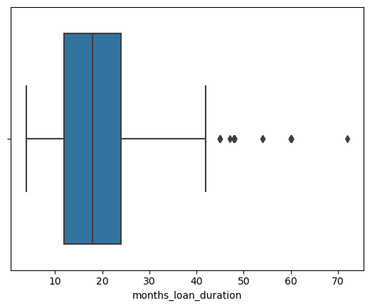

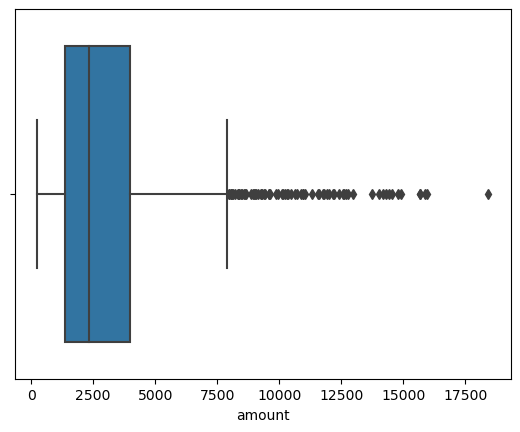

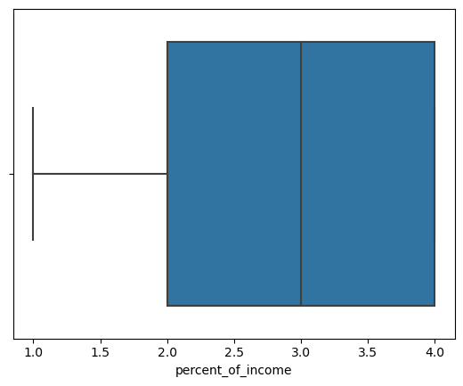

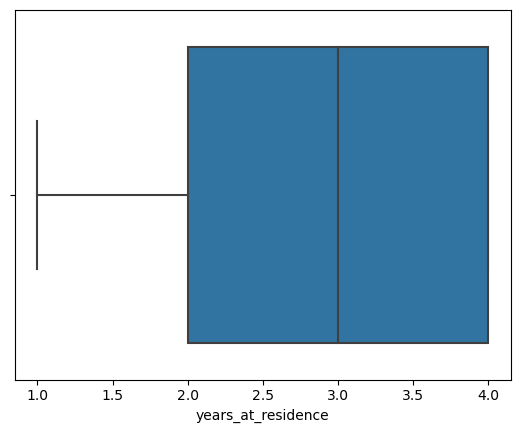

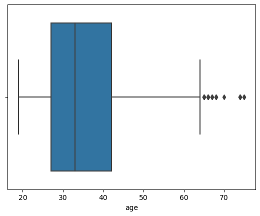

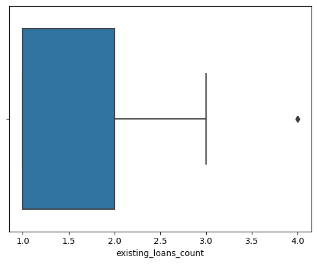

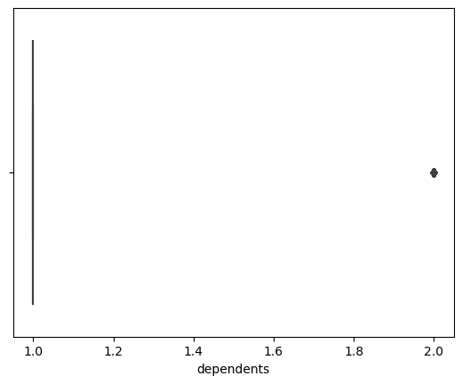

```python
num_cols=df.select_dtypes(include=np.number).columns.tolist()
fig, axes = plt.subplots(nrows=1, ncols=2, figsize=(12, 4))
for num_col in num_cols:
  sns.histplot(data=df,x=num_col,ax=axes[1],kde=True)
  plt.show()
  sns.boxplot(data=df,x=num_col)
  plt.show
```

### Observations:

- There are quite a few outliers in the data
- However, they look like proper values

## Numerical Data

```python
def histogram_boxplot(df, feature, figsize=(15, 10), kde=False, bins=None):
    """
    Boxplot and histogram combined


    data: dataframe
    feature: dataframe column
    figsize: size of figure (default (15,10))
    kde: whether to show the density curve (default False)
    bins: number of bins for histogram (default None)
    """
    f2, (ax_box2, ax_hist2) = plt.subplots(
        nrows=2,  # Number of rows of the subplot grid= 2
        sharex=True,  # x-axis will be shared among all subplots
        gridspec_kw={"height_ratios": (0.25, 0.75)},
        figsize=figsize,
    )  # creating the 2 subplots
    sns.boxplot(
        data=df, x=feature, ax=ax_box2, showmeans=True, color="violet"
    )  # boxplot will be created and a triangle will indicate the mean value of the column
    sns.histplot(
        data=df, x=feature, kde=kde, ax=ax_hist2, bins=bins
    ) if bins else sns.histplot(
        data=df, x=feature, kde=kde, ax=ax_hist2
    )  # For histogram
    ax_hist2.axvline(
        df[feature].mean(), color="green", linestyle="--"
    )  # Add mean to the histogram
    ax_hist2.axvline(
        df[feature].median(), color="black", linestyle="-"
    )  # Add median to the histogram
```

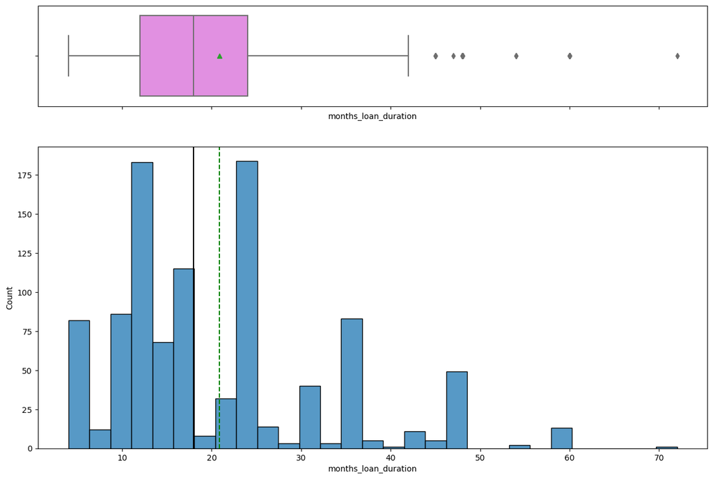

```python
histogram_boxplot(df,"months_loan_duration")
```

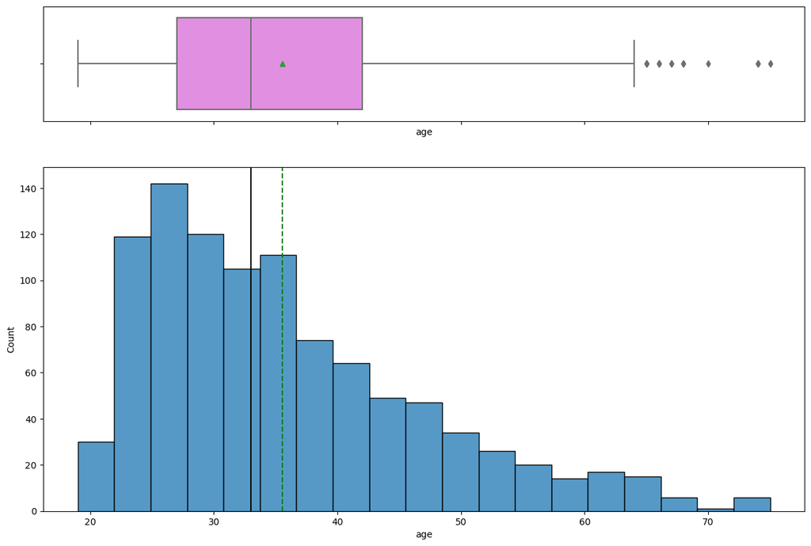

```python
histogram_boxplot(df,"age")
```

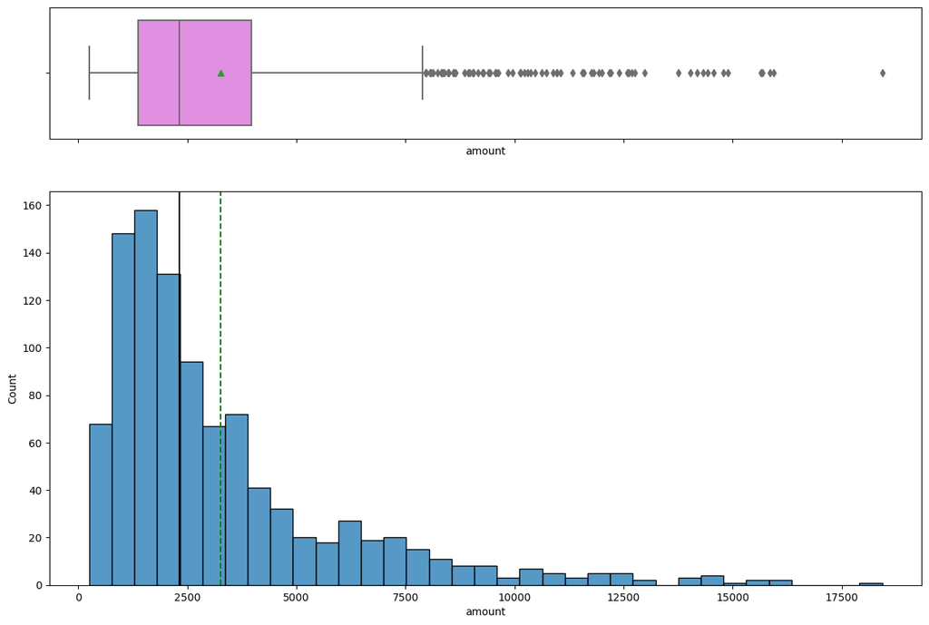

```python
histogram_boxplot(df,"amount")
```

## Categorical Data

```python
def labeled_barplot(df, feature, perc=False, n=None):
    """
    Barplot with percentage at the top


    data: dataframe
    feature: dataframe column
    perc: whether to display percentages instead of count (default is False)
    n: displays the top n category levels (default is None, i.e., display all levels)
    """


    total = len(df[feature])  # length of the column
    count = df[feature].nunique()
    if n is None:
        plt.figure(figsize=(count + 2, 6))
    else:
        plt.figure(figsize=(n + 2, 6))


    plt.xticks(rotation=90, fontsize=15)
    ax = sns.countplot(
        data=df,
        x=feature,
        palette="Paired",
        order=df[feature].value_counts().index[:n],
    )


    for p in ax.patches:
        if perc == True:
            label = "{:.1f}%".format(
                100 * p.get_height() / total
            )  # percentage of each class of the category
        else:
            label = p.get_height()  # count of each level of the category


        x = p.get_x() + p.get_width() / 2  # width of the plot
        y = p.get_height()  # height of the plot


        ax.annotate(
            label,
            (x, y),
            ha="center",
            va="center",
            size=12,
            xytext=(0, 5),
            textcoords="offset points",
        )  # annotate the percentage


    plt.show()  # show the plot
```

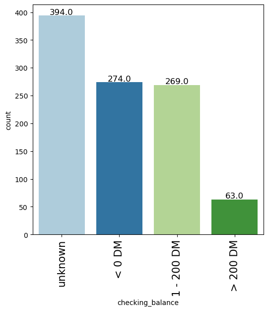

```python
labeled_barplot(df,"checking_balance")
```

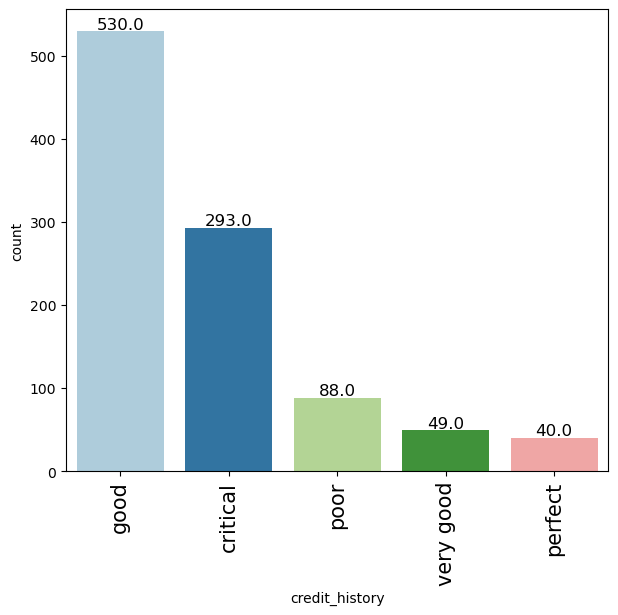

```python
labeled_barplot(df,"credit_history")
```

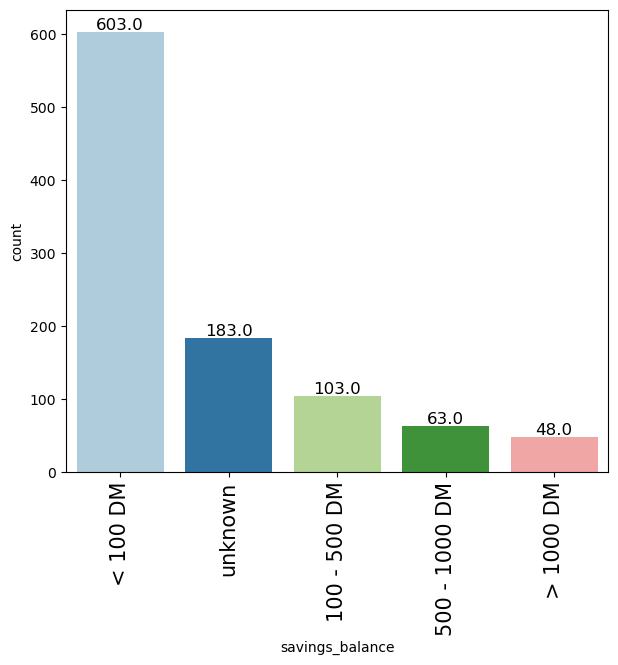

```python
labeled_barplot(df,"savings_balance")
```

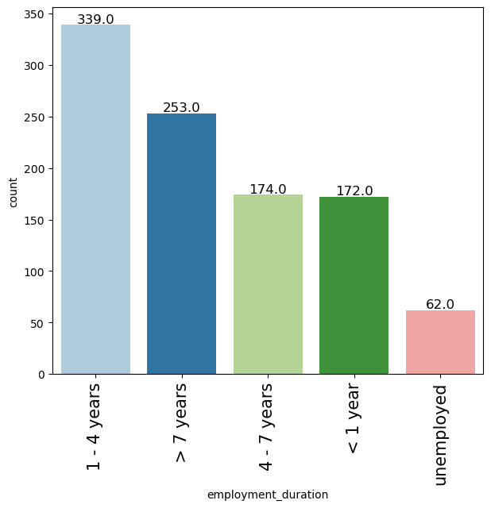

```python
labeled_barplot(df,"employment_duration")
```

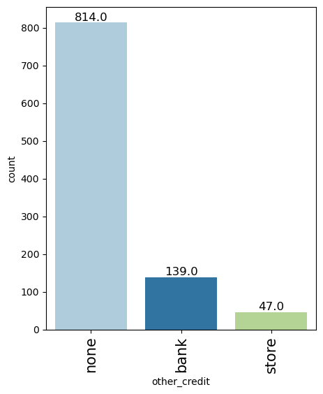

```python
labeled_barplot(df,"other_credit")
```

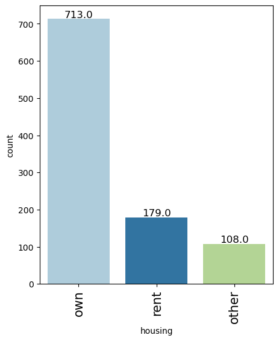

```python
labeled_barplot(df,"housing")
```

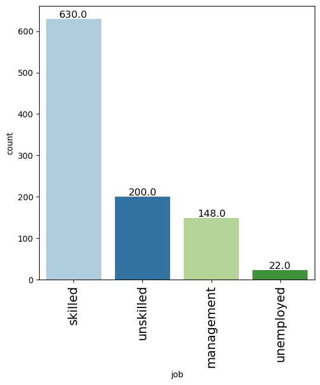

```python
labeled_barplot(df,"job")
```

## Bivariate Analysis

### This analysis will allow us to look deeper and see some of the reasons some associations with defaulting

- Any variations will be useful to build a better model.

```python
def distribution_plot_wrt_target(df, predictor, target):

    fig, axs = plt.subplots(2, 2, figsize=(12, 10))

    target_uniq = df[target].unique()

    axs[0, 0].set_title("Distribution of target for target=" + str(target_uniq[0]))
    sns.histplot(
        data=df[df[target] == target_uniq[0]],
        x=predictor,
        kde=True,
        ax=axs[0, 0],
        color="teal",
        stat="density",
    )

    axs[0, 1].set_title("Distribution of target for target=" + str(target_uniq[1]))
    sns.histplot(
        data=df[df[target] == target_uniq[1]],
        x=predictor,
        kde=True,
        ax=axs[0, 1],
        color="orange",
        stat="density",
    )

    axs[1, 0].set_title("Boxplot w.r.t target")
    sns.boxplot(data=df, x=target, y=predictor, ax=axs[1, 0], palette="gist_rainbow")

    axs[1, 1].set_title("Boxplot (without outliers) w.r.t target")
    sns.boxplot(
        data=df,
        x=target,
        y=predictor,
        ax=axs[1, 1],
        showfliers=False,
        palette="gist_rainbow",
    )

    plt.tight_layout()
    plt.show()
```

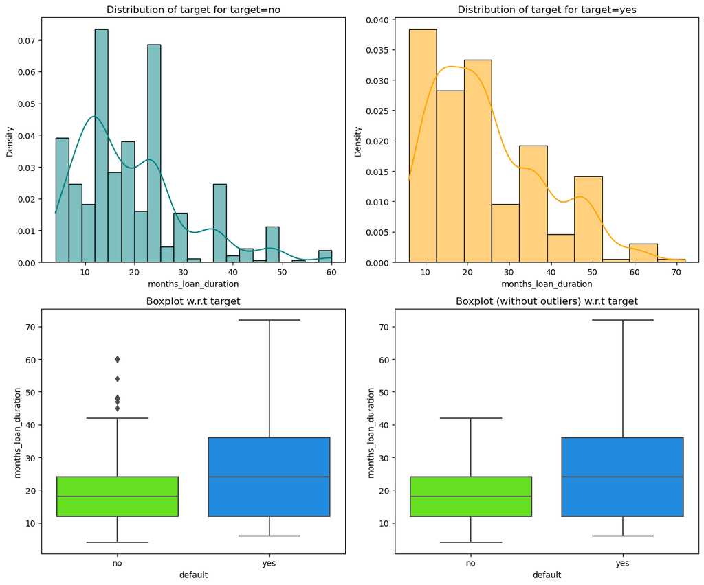

```python
distribution_plot_wrt_target(df, "months_loan_duration", "default")
```

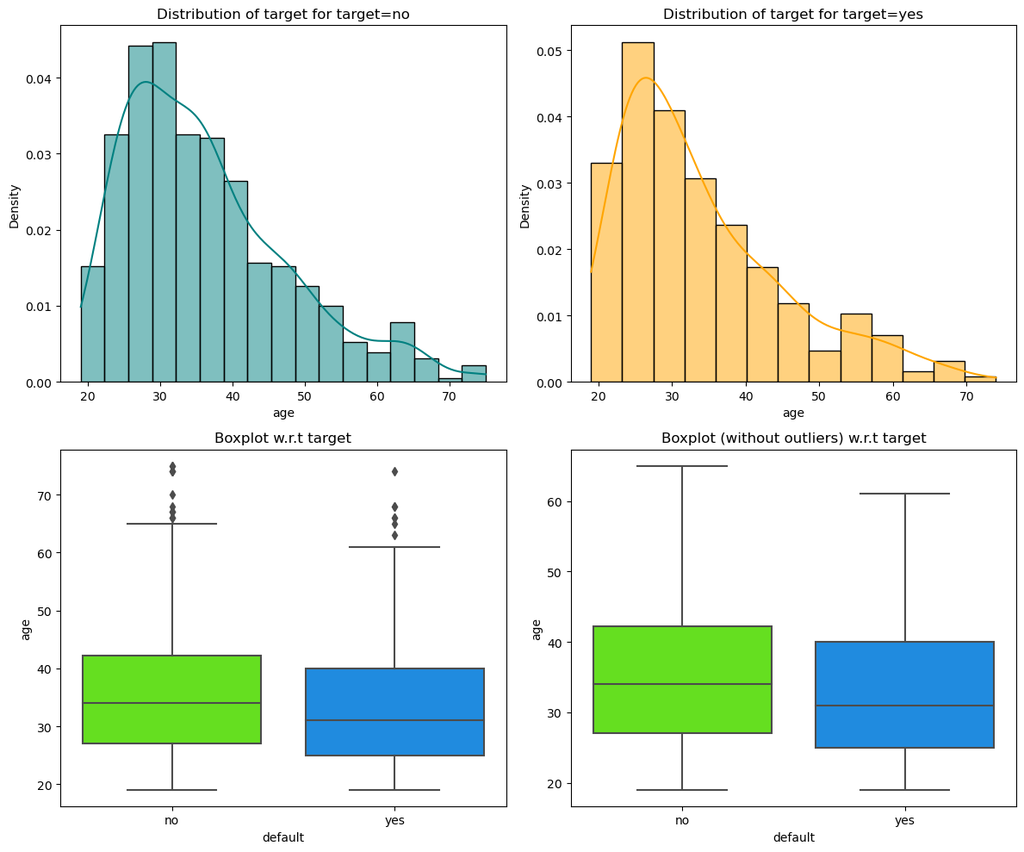

```python
distribution_plot_wrt_target(df, "age", "default")
```

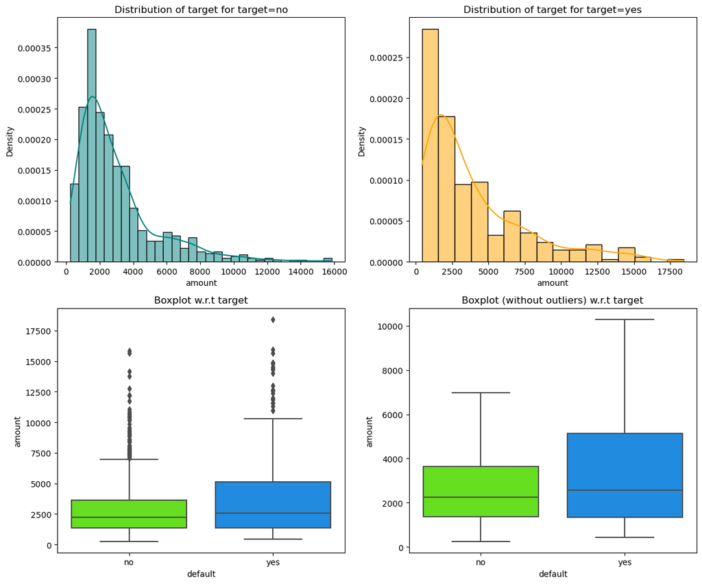

```python
distribution_plot_wrt_target(df, "amount", "default")
```

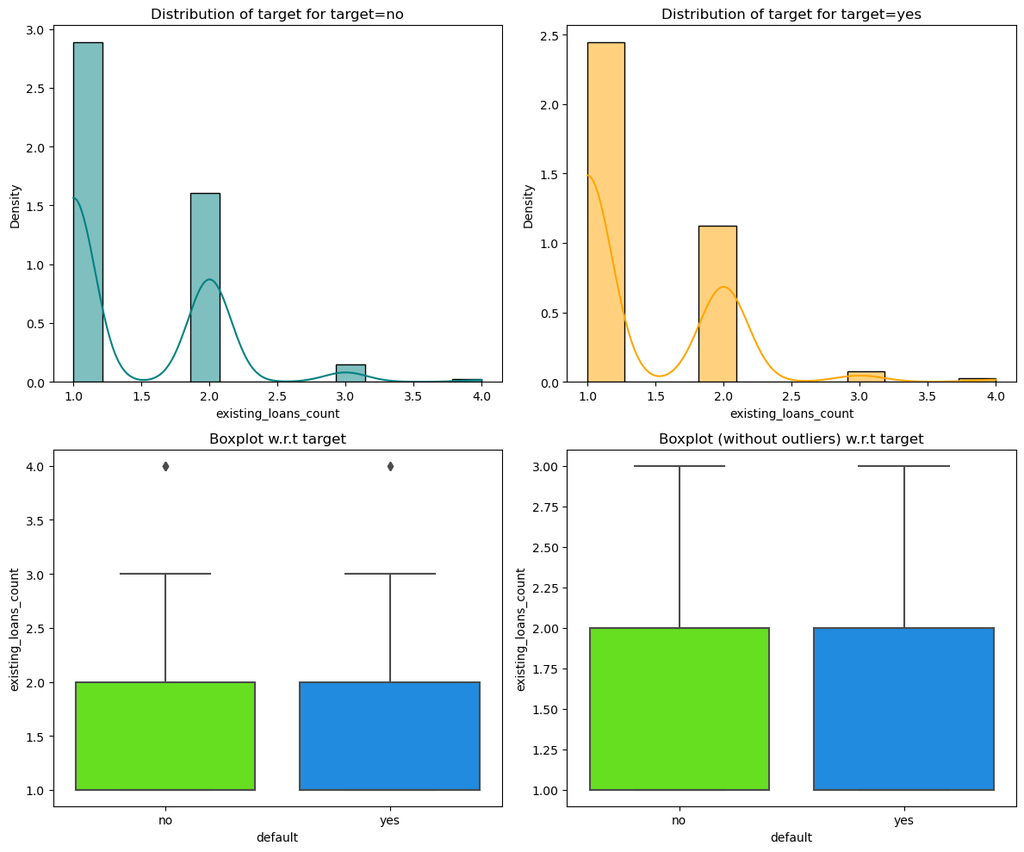

```python
distribution_plot_wrt_target(df, "existing_loans_count", "default")
```

### Converting Categorical Data to Numerical

- This is essential firstly to be able to deprive more insights from the EDA and secoundly as this will be essential in classification.

```python
df2 = df.copy()
```

### Note

In order to replace the variables appropriately I will need to assess the rankings of each one. e.g the credit history would need to be assessed based on a rank instead of amount in data set. So it would be {"critical": 1, "poor":2 , "good": 3, "very good": 4,"perfect": 5}, NOT { 1.good:530, 2.critical 293,3.poor 88} etc.

```python
replaceStruct = {
                "checking_balance":     {"< 0 DM": 1, "1 - 200 DM": 2 ,"> 200 DM": 3 ,"unknown":-1},
                "credit_history": {"critical": 1, "poor":2 , "good": 3, "very good": 4,"perfect": 5},
                 "savings_balance": {"< 100 DM": 1, "100 - 500 DM":2 , "500 - 1000 DM": 3, "> 1000 DM": 4,"unknown": -1},
                 "employment_duration":     {"unemployed": 1, "< 1 year": 2 ,"1 - 4 years": 3 ,"4 - 7 years": 4 ,"> 7 years": 5},
                "phone":     {"no": 1, "yes": 2 },
                #"job":     {"unemployed": 1, "unskilled": 2, "skilled": 3, "management": 4 },
                "default":     {"no": 0, "yes": 1 }
                    }
```

Some columns although numerical but would still benefit from one hot encoding, this would enable the model to learn more effectively and improve classification accuracy.

```python
oneHotCols=["purpose","housing","other_credit","job"]
```

```python
df2=df2.replace(replaceStruct)
df2=pd.get_dummies(df2, columns=oneHotCols)
```

```python
df2.info()
```

```
<class 'pandas.core.frame.DataFrame'>
RangeIndex: 1000 entries, 0 to 999
Data columns (total 29 columns):
 #   Column                        Non-Null Count  Dtype
---  ------                        --------------  -----
 0   checking_balance              1000 non-null   int64
 1   months_loan_duration          1000 non-null   int64
 2   credit_history                1000 non-null   int64
 3   amount                        1000 non-null   int64
 4   savings_balance               1000 non-null   int64
 5   employment_duration           1000 non-null   int64
 6   percent_of_income             1000 non-null   int64
 7   years_at_residence            1000 non-null   int64
 8   age                           1000 non-null   int64
 9   existing_loans_count          1000 non-null   int64
```

[output cut: 21 more lines]

### Now that all the Dtypes are numerical we are able to start training the model.

## Train and Split the Data

```python
X = df2.drop("default" , axis=1)
y = df2.pop("default")
```

```python
X_train, X_test, y_train, y_test = train_test_split(X, y, test_size=.30, random_state=1)
```

## Building Decision Tree Model

```python
dTree = DecisionTreeClassifier(criterion = 'gini', random_state=1)
dTree.fit(X_train, y_train)
```

```
DecisionTreeClassifier(random_state=1)
```

## Scoring Decision Tree

```python
print("Accuracy on training set : ",dTree.score(X_train, y_train))
print("Accuracy on test set : ",dTree.score(X_test, y_test))
```

```
Accuracy on training set :  1.0
Accuracy on test set :  0.6933333333333334
```

## Which Metric should be used for this problem

- When considering these losses, the more significant concern revolves around customers not fulfilling their repayment obligations. To effectively address this issue and mitigate the risk of defaults, it is advisable to prioritize the use of Recall as a metric for evaluating models, instead of focusing solely on accuracy.
- Recall, a metric that measures the ratio of True Positives to Actual Positives, is particularly pertinent in this context. A higher Recall signifies a reduced occurrence of false negatives, indicating a lower likelihood of incorrectly classifying a defaulter as a non-defaulter. This strategic emphasis on Recall aligns with the overarching goal of minimizing the associated risks of non-repayment by customers.

### Function to create confusion matrix

```python
def confusion_matrix(model,y_actual,labels=[1, 0]):
    '''
    model : classifier to predict values of X
    y_actual : ground truth

    '''
    y_predict = model.predict(X_test)
    cm=metrics.confusion_matrix( y_actual, y_predict, labels=[0, 1])
    df_cm = pd.DataFrame(cm, index = [i for i in ["Actual - No","Actual - Yes"]],
                  columns = [i for i in ['Predicted - No','Predicted - Yes']])
    group_counts = ["{0:0.0f}".format(value) for value in
                cm.flatten()]
    group_percentages = ["{0:.2%}".format(value) for value in
                         cm.flatten()/np.sum(cm)]
    labels = [f"{v1}\n{v2}" for v1, v2 in
              zip(group_counts,group_percentages)]
    labels = np.asarray(labels).reshape(2,2)
    plt.figure(figsize = (10,7))
    sns.heatmap(df_cm, annot=labels,fmt='')
    plt.ylabel('True label')
    plt.xlabel('Predicted label')
```

### Function to calculate recall score

```python
def recall_score(model):
    '''
    model : classifier to predict values of X

    '''
    pred_train = model.predict(X_train)
    pred_test = model.predict(X_test)
    print("Recall on training set : ",metrics.recall_score(y_train,pred_train))
    print("Recall on test set : ",metrics.recall_score(y_test,pred_test))
```

## Confusion Matrix

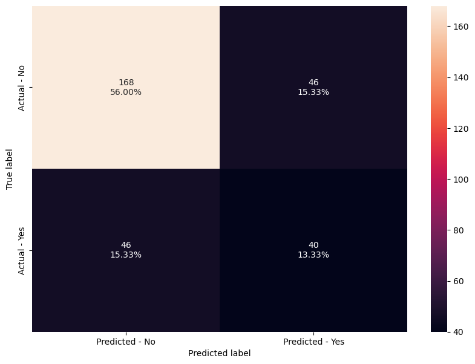

```python
confusion_matrix(dTree,y_test)
```

### Recall on train and test

```python
recall_score(dTree)
```

```
Recall on training set :  1.0
Recall on test set :  0.46511627906976744
```

## Descion Tree

```python
feature_names = list(X.columns)
print(feature_names)
```

```
['checking_balance', 'months_loan_duration', 'credit_history', 'amount', 'savings_balance', 'employment_duration', 'percent_of_income', 'years_at_residence', 'age', 'existing_loans_count', 'dependents', 'phone', 'purpose_business', 'purpose_car', 'purpose_car0', 'purpose_education', 'purpose_furnitu…
```

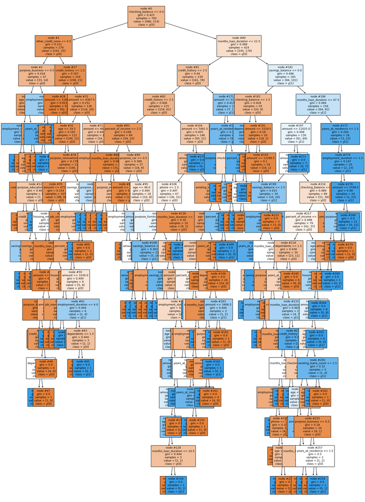

```python
plt.figure(figsize=(20,30))
tree.plot_tree(dTree,feature_names=feature_names,filled=True,fontsize=9,node_ids=True,class_names=True)
plt.show()
```

### Text report of the Descion Tree

```python
print(tree.export_text(dTree,feature_names=feature_names,show_weights=True))
```

```
|--- checking_balance <= 0.00
|   |--- other_credit_none <= 0.50
|   |   |--- purpose_business <= 0.50
|   |   |   |--- age <= 25.50
|   |   |   |   |--- employment_duration <= 3.50
|   |   |   |   |   |--- weights: [0.00, 3.00] class: 1
|   |   |   |   |--- employment_duration >  3.50
|   |   |   |   |   |--- weights: [1.00, 0.00] class: 0
|   |   |   |--- age >  25.50
|   |   |   |   |--- age <= 38.50
|   |   |   |   |   |--- age <= 31.50
|   |   |   |   |   |   |--- credit_history <= 4.50
|   |   |   |   |   |   |   |--- weights: [13.00, 0.00] class: 0
|   |   |   |   |   |   |--- credit_history >  4.50
|   |   |   |   |   |   |   |--- weights: [0.00, 1.00] class: 1
|   |   |   |   |   |--- age >  31.50
|   |   |   |   |   |   |--- purpose_education <= 0.50
|   |   |   |   |   |   |   |--- credit_history <= 1.50
|   |   |   |   |   |   |   |   |--- savings_balance <= 2.50
|   |   |   |   |   |   |   |   |   |--- weights: [0.00, 2.00] class: 1
|   |   |   |   |   |   |   |   |--- savings_balance >  2.50
|   |   |   |   |   |   |   |   |   |--- weights: [1.00, 0.00] class: 0
|   |   |   |   |   |   |   |--- credit_history >  1.50
|   |   |   |   |   |   |   |   |--- savings_balance <= 2.50
|   |   |   |   |   |   |   |   |   |--- weights: [6.00, 0.00] class: 0
|   |   |   |   |   |   |   |   |--- savings_balance >  2.50
|   |   |   |   |   |   |   |   |   |--- weights: [0.00, 1.00] class: 1
|   |   |   |   |   |   |--- purpose_education >  0.50
|   |   |   |   |   |   |   |--- weights: [0.00, 1.00] class: 1
|   |   |   |   |--- age >  38.50
|   |   |   |   |   |--- weights: [9.00, 0.00] class: 0
|   |   |--- purpose_business >  0.50
|   |   |   |--- employment_duration <= 4.00
|   |   |   |   |--- years_at_residence <= 1.50
|   |   |   |   |   |--- weights: [1.00, 0.00] class: 0
|   |   |   |   |--- years_at_residence >  1.50
|   |   |   |   |   |--- weights: [0.00, 6.00] class: 1
|   |   |   |--- employment_duration >  4.00
|   |   |   |   |--- weights: [2.00, 0.00] class: 0
|   |--- other_credit_none >  0.50
```

[output cut: 276 more lines]

```
|   |   |   |   |   |--- weights: [0.00, 7.00] class: 1
|   |   |   |--- months_loan_duration >  47.50
|   |   |   |   |--- years_at_residence <= 1.50
|   |   |   |   |   |--- weights: [1.00, 0.00] class: 0
|   |   |   |   |--- years_at_residence >  1.50
|   |   |   |   |   |--- employment_duration <= 1.50
|   |   |   |   |   |   |--- weights: [1.00, 0.00] class: 0
|   |   |   |   |   |--- employment_duration >  1.50
|   |   |   |   |   |   |--- amount <= 3748.50
|   |   |   |   |   |   |   |--- purpose_business <= 0.50
|   |   |   |   |   |   |   |   |--- weights: [0.00, 2.00] class: 1
|   |   |   |   |   |   |   |--- purpose_business >  0.50
|   |   |   |   |   |   |   |   |--- weights: [1.00, 0.00] class: 0
|   |   |   |   |   |   |--- amount >  3748.50
|   |   |   |   |   |   |   |--- weights: [0.00, 21.00] class: 1
```

### Gini importance of the features

```python
print (pd.DataFrame(dTree.feature_importances_, columns = ["Imp"], index = X_train.columns).sort_values(by = 'Imp', ascending = False))
```

```
                                   Imp
amount                        0.204163
checking_balance              0.136840
age                           0.110746
months_loan_duration          0.100323
employment_duration           0.073225
credit_history                0.065357
savings_balance               0.057059
years_at_residence            0.052719
percent_of_income             0.034128
purpose_business              0.023784
dependents                    0.023062
purpose_car                   0.021217
phone                         0.016737
housing_rent                  0.016646
purpose_education             0.013767
existing_loans_count          0.013575
purpose_furniture/appliances  0.012421
other_credit_none             0.011156
job_management                0.005769
purpose_renovations           0.004489
job_unskilled                 0.002818
other_credit_bank             0.000000
housing_own                   0.000000
other_credit_store            0.000000
housing_other                 0.000000
job_skilled                   0.000000
job_unemployed                0.000000
purpose_car0                  0.000000
```

### Feature Importance Visualised

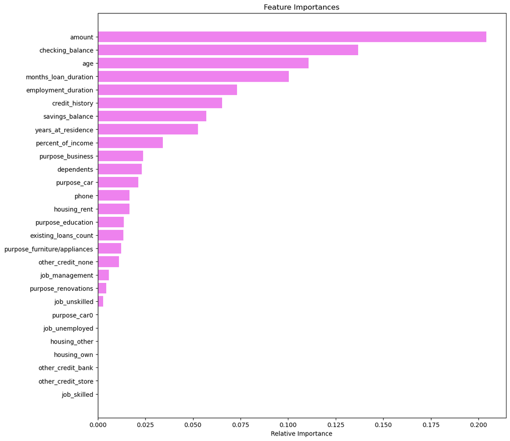

```python
importances = dTree.feature_importances_
indices = np.argsort(importances)

plt.figure(figsize=(12,12))
plt.title('Feature Importances')
plt.barh(range(len(indices)), importances[indices], color='violet', align='center')
plt.yticks(range(len(indices)), [feature_names[i] for i in indices])
plt.xlabel('Relative Importance')
plt.show()
```

### Feature Importance

- Due to overfitting a lot of features have a very high importance.
- The most important features mentioned in this model are the amount, checking balance and age.

### This tree is extremely complex and obviously there is a lot of overfitting present. We will try limiting the max depth of the tree to reduce overfitting.

## Decsion Tree (reduced max depth)

```python
dTree1 = DecisionTreeClassifier(criterion = 'gini',max_depth=3,random_state=1)
dTree1.fit(X_train, y_train)
```

```
DecisionTreeClassifier(max_depth=3, random_state=1)
```

## Confusion Matrix

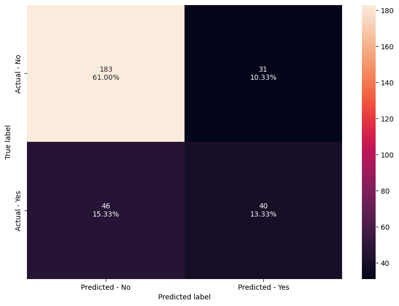

```python
confusion_matrix(dTree1, y_test)
```

### Accuracy on train and test

```python
print("Accuracy on training set : ",dTree1.score(X_train, y_train))
print("Accuracy on test set : ",dTree1.score(X_test, y_test))
```

```
Accuracy on training set :  0.7528571428571429
Accuracy on test set :  0.7433333333333333
```

### Recall on train and test

```python
recall_score(dTree1)
```

```
Recall on training set :  0.5373831775700935
Recall on test set :  0.46511627906976744
```

### Visualizing the Decision Tree

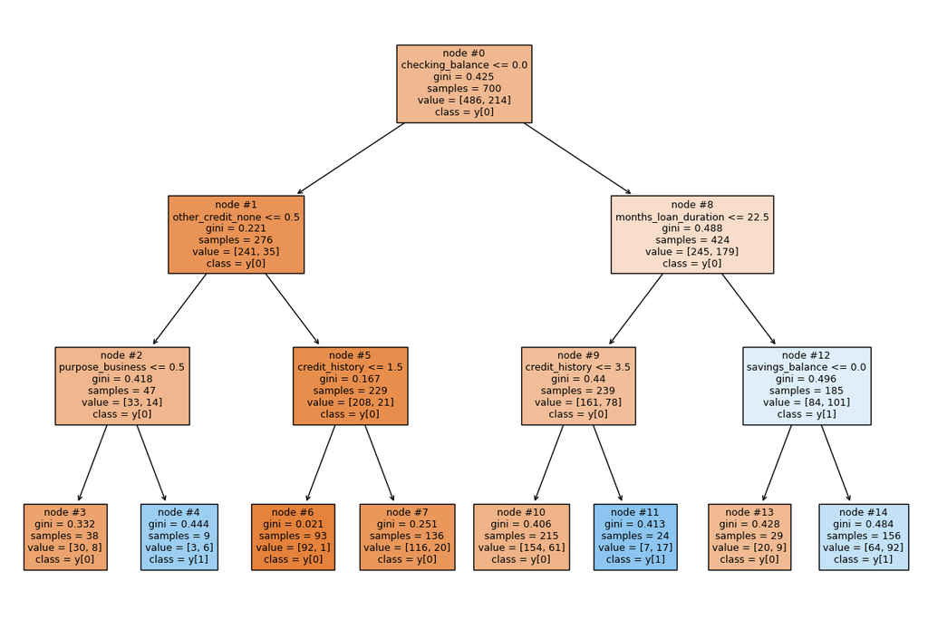

```python
plt.figure(figsize=(15,10))

tree.plot_tree(dTree1,feature_names=feature_names,filled=True,fontsize=9,node_ids=True,class_names=True)
plt.show()
```

### Text report of decision tree

```python
print(tree.export_text(dTree1,feature_names=feature_names,show_weights=True))
```

```
|--- checking_balance <= 0.00
|   |--- other_credit_none <= 0.50
|   |   |--- purpose_business <= 0.50
|   |   |   |--- weights: [30.00, 8.00] class: 0
|   |   |--- purpose_business >  0.50
|   |   |   |--- weights: [3.00, 6.00] class: 1
|   |--- other_credit_none >  0.50
|   |   |--- credit_history <= 1.50
|   |   |   |--- weights: [92.00, 1.00] class: 0
|   |   |--- credit_history >  1.50
|   |   |   |--- weights: [116.00, 20.00] class: 0
|--- checking_balance >  0.00
|   |--- months_loan_duration <= 22.50
|   |   |--- credit_history <= 3.50
|   |   |   |--- weights: [154.00, 61.00] class: 0
|   |   |--- credit_history >  3.50
|   |   |   |--- weights: [7.00, 17.00] class: 1
|   |--- months_loan_duration >  22.50
|   |   |--- savings_balance <= 0.00
|   |   |   |--- weights: [20.00, 9.00] class: 0
|   |   |--- savings_balance >  0.00
|   |   |   |--- weights: [64.00, 92.00] class: 1
```

### Gini importance of the features

```python
print (pd.DataFrame(dTree1.feature_importances_, columns = ["Imp"], index = X_train.columns).sort_values(by = 'Imp', ascending = False))
```

```
                                   Imp
checking_balance              0.492510
months_loan_duration          0.169806
credit_history                0.166109
savings_balance               0.064467
other_credit_none             0.055977
purpose_business              0.051129
purpose_furniture/appliances  0.000000
job_unemployed                0.000000
job_skilled                   0.000000
job_management                0.000000
other_credit_store            0.000000
other_credit_bank             0.000000
housing_rent                  0.000000
housing_own                   0.000000
housing_other                 0.000000
purpose_renovations           0.000000
purpose_car0                  0.000000
purpose_education             0.000000
purpose_car                   0.000000
phone                         0.000000
dependents                    0.000000
existing_loans_count          0.000000
age                           0.000000
years_at_residence            0.000000
percent_of_income             0.000000
employment_duration           0.000000
amount                        0.000000
job_unskilled                 0.000000
```

### Feature Importance Visualised

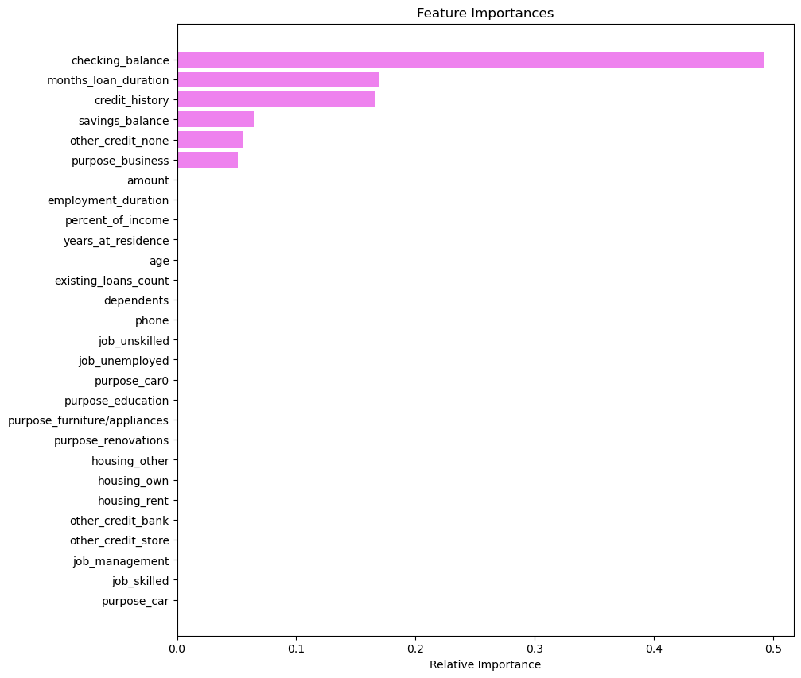

```python
importances = dTree1.feature_importances_
indices = np.argsort(importances)

plt.figure(figsize=(10,10))
plt.title('Feature Importances')
plt.barh(range(len(indices)), importances[indices], color='violet', align='center')
plt.yticks(range(len(indices)), [feature_names[i] for i in indices])
plt.xlabel('Relative Importance')
plt.show()
```

### Observation:

- Previous model highlighted key features such as 'checking_balance', 'months_loan_duration', and 'credit_history', while 'amount' showed no importance, revealing a limitation of pre-pruning methods.
- Pre-pruning may prematurely restrict feature exploration, leading to overlooked insights and suboptimal model performance, particularly evident when 'max_depth' is set too low, causing underfitting.
- Employing grid search techniques enables systematic evaluation of hyperparameters, such as 'max_depth', to strike a balance between model complexity and predictive accuracy, enhancing overall performance and robustness.

## GridSearch for Hyperparameter tuning of our tree model

```python
from sklearn.model_selection import GridSearchCV
```

```python
# Choose the type of classifier.
estimator = DecisionTreeClassifier(random_state=1)

# Grid of parameters to choose from
## add from article
parameters = {'max_depth': np.arange(1,10),
              'min_samples_leaf': [1, 2, 5, 7, 10,15,20],
              'max_leaf_nodes' : [2, 3, 5, 10],
              'min_impurity_decrease': [0.001,0.01,0.1]
             }

# Type of scoring used to compare parameter combinations
acc_scorer = metrics.make_scorer(metrics.recall_score)

# Run the grid search
grid_obj = GridSearchCV(estimator, parameters, scoring=acc_scorer,cv=5)
grid_obj = grid_obj.fit(X_train, y_train)

# Set the clf to the best combination of parameters
estimator = grid_obj.best_estimator_

# Fit the best algorithm to the data.
estimator.fit(X_train, y_train)
```

```
DecisionTreeClassifier(max_depth=4, max_leaf_nodes=10,
                       min_impurity_decrease=0.001, min_samples_leaf=20,
                       random_state=1)
```

### Confusion Matrix - Tuned Hyperparameters

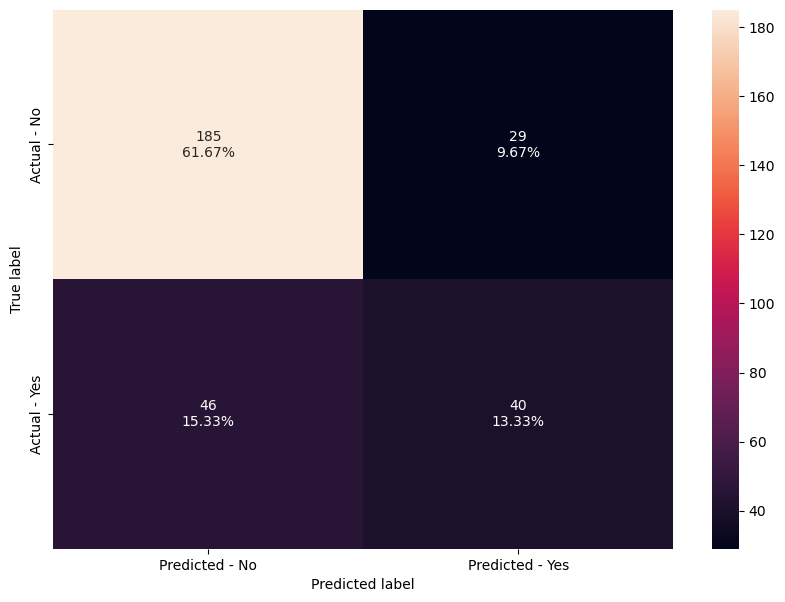

```python
confusion_matrix(estimator,y_test)
```

### Accuracy on train and test

```python
print("Accuracy on training set : ",estimator.score(X_train, y_train))
print("Accuracy on test set : ",estimator.score(X_test, y_test))
```

```
Accuracy on training set :  0.7485714285714286
Accuracy on test set :  0.75
```

### Recall on train and test

```python
recall_score(estimator)
```

```
Recall on training set :  0.5093457943925234
Recall on test set :  0.46511627906976744
```

### Visualizing the Decision Tree

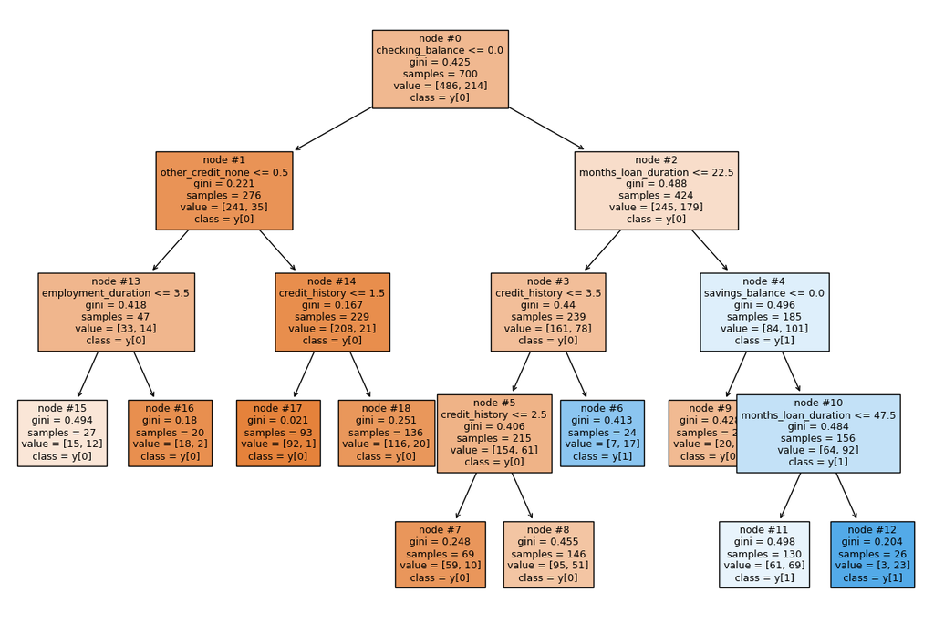

```python
plt.figure(figsize=(15,10))

tree.plot_tree(estimator,feature_names=feature_names,filled=True,fontsize=9,node_ids=True,class_names=True)
plt.show()
```

### Text report of decision tree:

```python
print(tree.export_text(estimator,feature_names=feature_names,show_weights=True))
```

```
|--- checking_balance <= 0.00
|   |--- other_credit_none <= 0.50
|   |   |--- employment_duration <= 3.50
|   |   |   |--- weights: [15.00, 12.00] class: 0
|   |   |--- employment_duration >  3.50
|   |   |   |--- weights: [18.00, 2.00] class: 0
|   |--- other_credit_none >  0.50
|   |   |--- credit_history <= 1.50
|   |   |   |--- weights: [92.00, 1.00] class: 0
|   |   |--- credit_history >  1.50
|   |   |   |--- weights: [116.00, 20.00] class: 0
|--- checking_balance >  0.00
|   |--- months_loan_duration <= 22.50
|   |   |--- credit_history <= 3.50
|   |   |   |--- credit_history <= 2.50
|   |   |   |   |--- weights: [59.00, 10.00] class: 0
|   |   |   |--- credit_history >  2.50
|   |   |   |   |--- weights: [95.00, 51.00] class: 0
|   |   |--- credit_history >  3.50
|   |   |   |--- weights: [7.00, 17.00] class: 1
|   |--- months_loan_duration >  22.50
|   |   |--- savings_balance <= 0.00
|   |   |   |--- weights: [20.00, 9.00] class: 0
|   |   |--- savings_balance >  0.00
|   |   |   |--- months_loan_duration <= 47.50
|   |   |   |   |--- weights: [61.00, 69.00] class: 1
|   |   |   |--- months_loan_duration >  47.50
|   |   |   |   |--- weights: [3.00, 23.00] class: 1
```

### Gini importance of the features

```python
print (pd.DataFrame(estimator.feature_importances_, columns = ["Imp"], index = X_train.columns).sort_values(by = 'Imp', ascending = False))
```

```
                                   Imp
checking_balance              0.427296
months_loan_duration          0.226805
credit_history                0.201464
savings_balance               0.055931
other_credit_none             0.048565
employment_duration           0.039938
purpose_furniture/appliances  0.000000
job_unemployed                0.000000
job_skilled                   0.000000
job_management                0.000000
other_credit_store            0.000000
other_credit_bank             0.000000
housing_rent                  0.000000
housing_own                   0.000000
housing_other                 0.000000
purpose_renovations           0.000000
purpose_car0                  0.000000
purpose_education             0.000000
purpose_car                   0.000000
purpose_business              0.000000
phone                         0.000000
dependents                    0.000000
existing_loans_count          0.000000
age                           0.000000
years_at_residence            0.000000
percent_of_income             0.000000
amount                        0.000000
job_unskilled                 0.000000
```

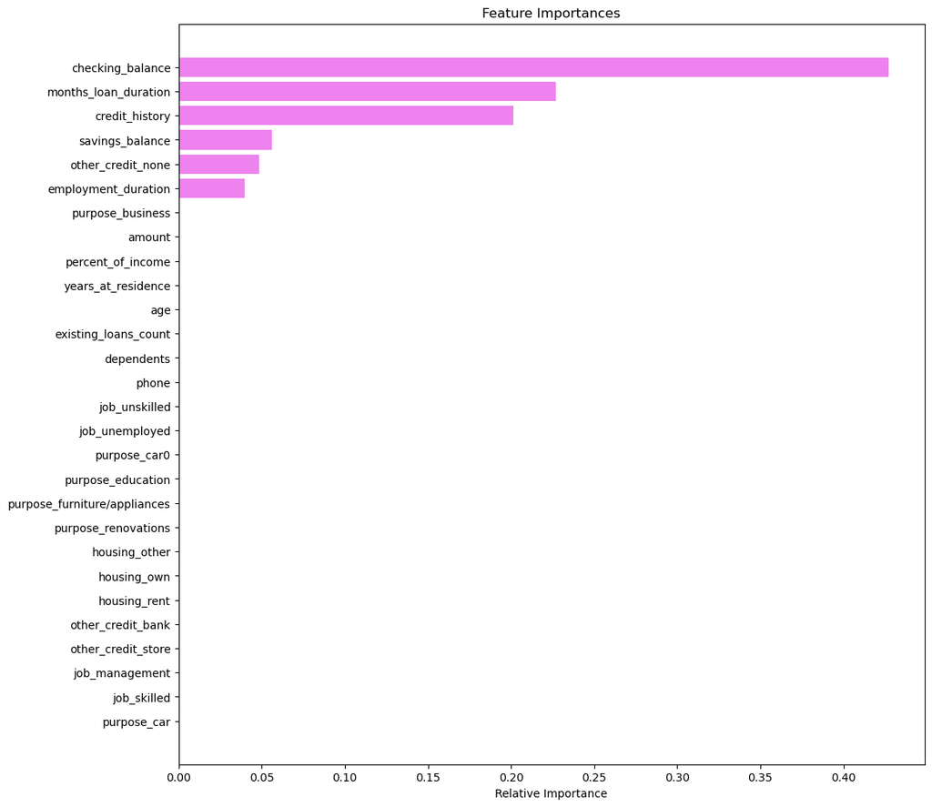

```python
importances = estimator.feature_importances_
indices = np.argsort(importances)

plt.figure(figsize=(12,12))
plt.title('Feature Importances')
plt.barh(range(len(indices)), importances[indices], color='violet', align='center')
plt.yticks(range(len(indices)), [feature_names[i] for i in indices])
plt.xlabel('Relative Importance')
plt.show()
```